# Assignment 1

# Task 1: Literature

> Developmental landscape of human forebrain at a single-cell level identifies early waves of oligodendrogenesis. David van Bruggen, et al. PMID: 35523173

### Q1. What is the medically relevant insight from the article?

This study doesn’t focus on any medical trait, and thus the medical relevance is not mentioned in the paper. However, oligodendrocyte precursor cells have been linked to psychiatric disorders like schizophrenia and bipolar disorder, so findings from this study might help understand the neural mechanisms of mental disorders.

### Q2. Which genomics technology/ technologies were used?

single-cell RNA sequencing: examining the identity of cells based on gene expression profiles

single-cell ATAC-seq: examining the chromatin accessibility, which is required for oligodentrogenesis

Spatial *in situ* sequencing: locating the sites for early human oligodendrogenesis

RNAscope HiPlex *in situ* hybridization: validating findings Spatial ISS analysis

### Q3. List and explain at least three questions/ hypotheses you can think of that extend the analysis presented in the paper.

1. How does oligodendrogenesis progress in midbrain and hidbrain (compared to forebrain)?
2. If the first wave of oligodendrogenesis is evolutionary conservative, are any later oligodendrogenesis waves less evolutionary conservative (i.e., more specific to humans)?
3. If the 2nd is true, are those less evolutionary conservative oligodendrogenesis waves with more individual differences (in for example time), and related to human-specific cognitive traits like intelligence and psychiatric disorders?

### Q4. [Optional] Devise a computational analysis strategy for (some of) the listed questions under 3a.

# Task 4: R basic operations

```r
cat('1. Square root of 10:', sqrt(10), '\n')
```

```
## 1. Square root of 10: 3.162278
```

```r
cat('2. Logarithm of 32 to the base 2:', log2(32), '\n')
```

```
## 2. Logarithm of 32 to the base 2: 5
```

```r
cat('3. the sum of the numbers from 1 to 1000:', sum(seq(1000)), '\n')
```

```
## 3. the sum of the numbers from 1 to 1000: 500500
```

```r
cat('4. the sum of all even numbers from 2 to 1000:', sum(seq(2, 1000, 2)), '\n')
```

```
## 4. the sum of all even numbers from 2 to 1000: 250500
```

```r
cat('5. the number of pairwise comparisons for 100 genes:', (100*100-100)/2, '\n')
```

```
## 5. the number of pairwise comparisons for 100 genes: 4950
```

```r
cat('6. the number of ways to arrange 100 genes in triplets:', factorial(100)/factorial(100-3), '\n')
```

```
## 6. the number of ways to arrange 100 genes in triplets: 970200
```

# Task 5: Using R example datasets

### 1. Load the CO2 dataset

```r
data('CO2')
```

### 2. Describe the dataset

```r
help(CO2)
cat('Description:\n', 'The CO2 data frame has 84 rows and 5 columns of data from an experiment on the cold tolerance of the grass species Echinochloa crus-galli.')
```

```
## Description:
##  The CO2 data frame has 84 rows and 5 columns of data from an experiment on the cold tolerance of the grass species Echinochloa crus-galli.
```

### 3. the average and median CO2 uptake of the plants from Quebec and Mississippi

```r
summary_uptake = data.frame()
cols_summary = c('type', 'mean', 'median')
types = c('Quebec', 'Mississippi')

# summary of each type
for (i in 1:length(types)) {
  type = types[i]
  uptake_type = na.exclude(CO2[CO2$Type == type, 'uptake'])

  summary_uptake[i, cols_summary] = c(type,
                                      round(mean(uptake_type), 2),
                                      round(median(uptake_type), 2))}

print(summary_uptake)
```

```
##          type  mean median
## 1      Quebec 33.54  37.15
## 2 Mississippi 20.88   19.3
```

### 4. [optional] genes expressed in each sample; genes not expressed in any sample

```r
# BiocManager::install("airway")
# library('airway')
# data('airway')
```

# Task 6: R Functions

### 1. A function calculating the ratio of the mean and the median of a vector

```r
mean_over_median = function(x) {
  x = na.exclude(x)
  ratio = mean(x)/median(x)
  return(ratio)
}

# test
print(mean_over_median(c(2, 2, 3, 4, 5)))
```

```
## [1] 1.066667
```

### 2. A function calculating the mean after discarding the min and the max

```r
mean_without_extreme = function(x) {
  x = na.exclude(x)
  x = x[(x != min(x)) & (x != max(x))]

  return(mean(x))
}

# test
mean_without_extreme(c(1, 2, 2, 5))
```

```
## [1] 2
```

### 3. Explaining “piping”

A pipe is discouraged when the included functions (1) have multiple inputs or outputs, (2) have a complex dependency, (3) use the current environment, or (4) use lazy evaluation. Besides, (5) piping too many intermediate steps/functions can make the code harder to read and debug.

### 4. Explaining “apply-family functions”

The apply-family functions are used to apply a function to each element in an iterable object. Though they won’t make the running more efficient, they replace a for-loop with a more compact code snippet. In other words, it seems like they only make the code look better.

# Task 7: Basic visualization with R

### 1. Compare the distributions of the body heights of the two species from the ‘magic_guys.csv’ dataset graphically

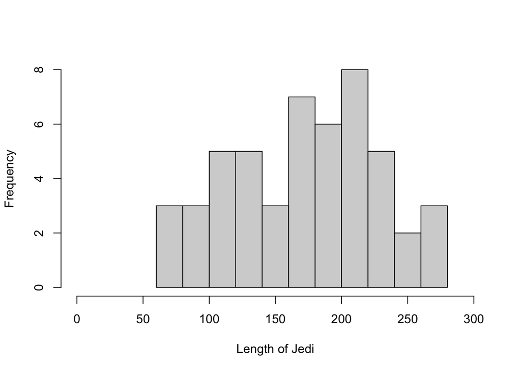

```r
library(ggplot2)
# with basic hist function: Length of Jedi
magic = read.csv('data/magic_guys.csv', header=T)
hist(magic[magic$species == 'jedi', 'length'], breaks=8, xlim=c(0, 300),
     xlab='Length of Jedi', main='')
```

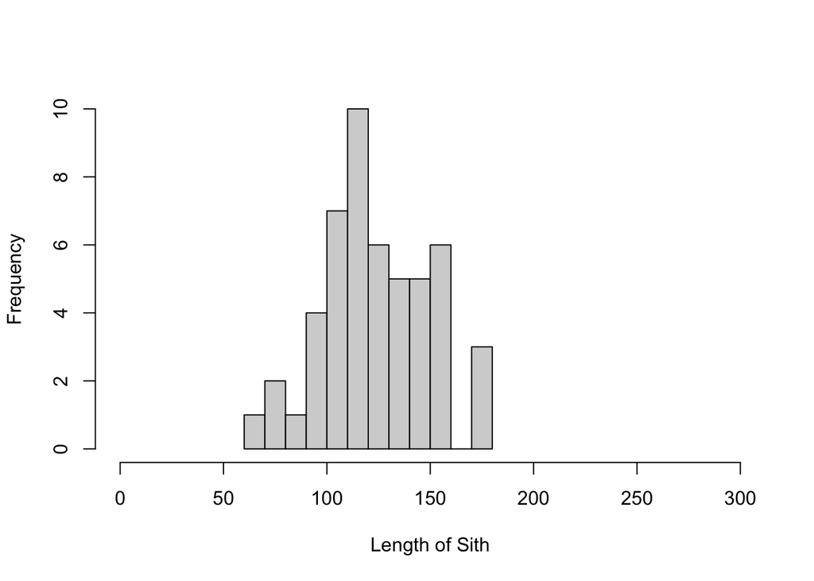

```r
# with basic hist function: Length of Sith
hist(magic[magic$species == 'sith', 'length'], breaks=8, xlim=c(0, 300),
     xlab='Length of Sith', main='')
```

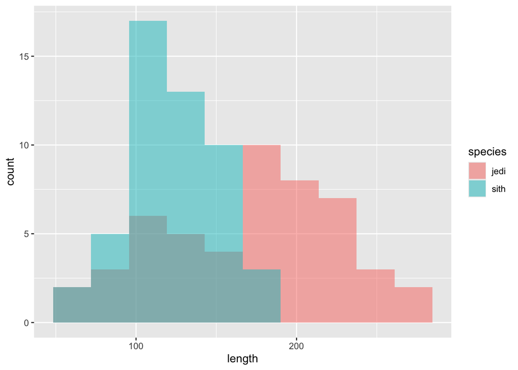

```r
# with ggplot and geom_histogram
n_bins = 10
hist_length = ggplot(magic, aes(x=length, fill=species)) +
  geom_histogram(bins=n_bins, alpha=0.5, position='identity')

ggsave("results/histogram_height.pdf", plot=hist_length)
ggsave("results/histogram_height.png", plot=hist_length)
ggsave("results/histogram_height.svg", plot=hist_length)
print(hist_length)
```

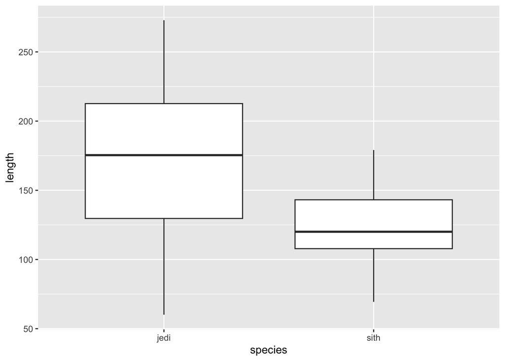

```r
box_height = ggplot(magic, aes(x=species, y=length)) +
  geom_boxplot()
ggsave("results/box_height.pdf", plot=box_height)
ggsave("results/box_height.png", plot=box_height)
ggsave("results/box_height.svg", plot=box_height)
print(box_height)
```

Formats of ‘pdf’ and ‘svg’ are usually preferred, as they are vector graphics, which has high image quality, small file size, while allows for editing later.

### 2. Inspect and visualize ‘microarray_data.tab’

```r
microarray = read.table('data/microarray_data.tab', sep='\t', header=T)
# a. inspect the size of the data frame
print(sprintf('The matrix has %s rows and %s columns', nrow(microarray), ncol(microarray)))
```

```
## [1] "The matrix has 553 rows and 1000 columns"
```

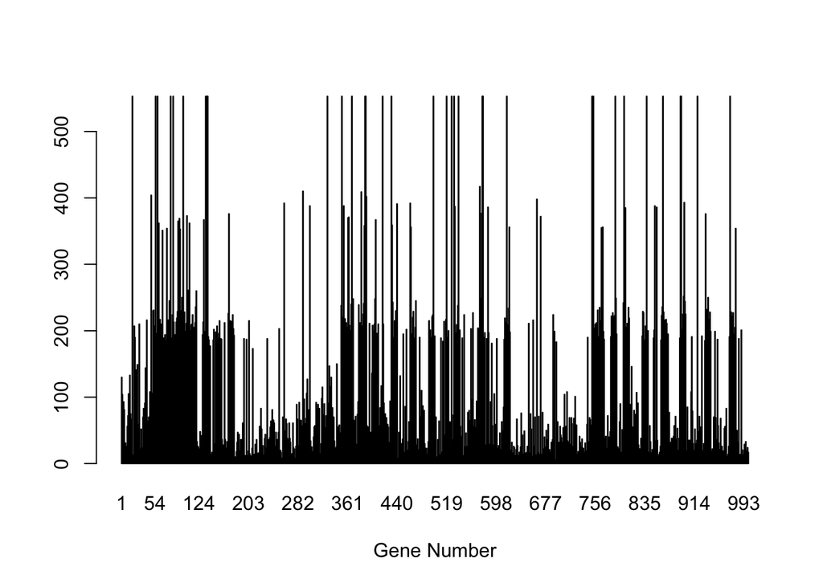

```r
# b. visualize the number of missing values per gene
counts_missing = apply(is.na(microarray), 2, sum)
names(counts_missing) = as.numeric(gsub('g', '', names(counts_missing)))
barplot(counts_missing, xlab='Gene Number')
```

```r
# c. find genes with specified missing rates
# define the function for searching
find_missing_genes = function(df, miss_rate) {
  counts_missing  = apply(is.na(df), 2, sum)
  percent_missing = counts_missing/nrow(df)

  list_result_genes = names(percent_missing[percent_missing > miss_rate])
  return(list_result_genes)
}

# apply the function and report the results
for (rate in c(0.1, 0.2, 0.5)) {
  num_genes = length(find_missing_genes(microarray, rate))
  print(sprintf('%s genes with missing rate > %s', num_genes, rate))
}
```

```
## [1] "529 genes with missing rate > 0.1"
## [1] "377 genes with missing rate > 0.2"
## [1] "74 genes with missing rate > 0.5"
```

```r
# d. replacing missing values with the average expression
for (col in names(microarray)) {
  microarray[is.na(microarray[, col]), col] = mean(microarray[, col], na.rm=T)
}
```

### 3. Visualize the CO2 data

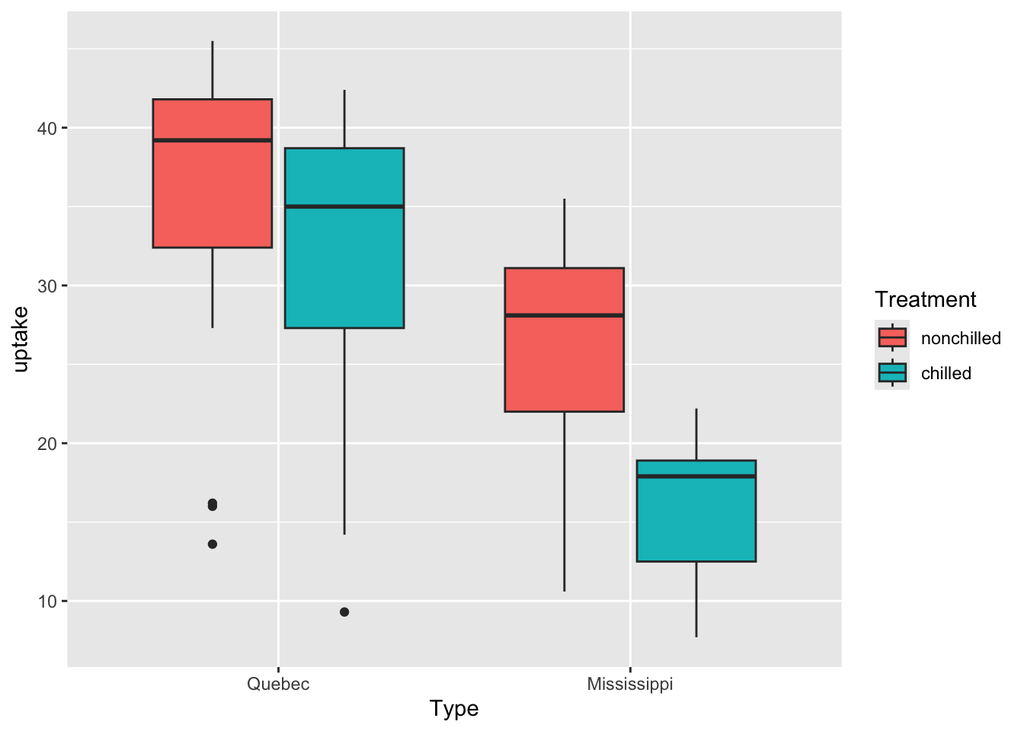

```r
ggplot(CO2, aes(x=Type, y=uptake, fill=Treatment)) +
  geom_boxplot()
```

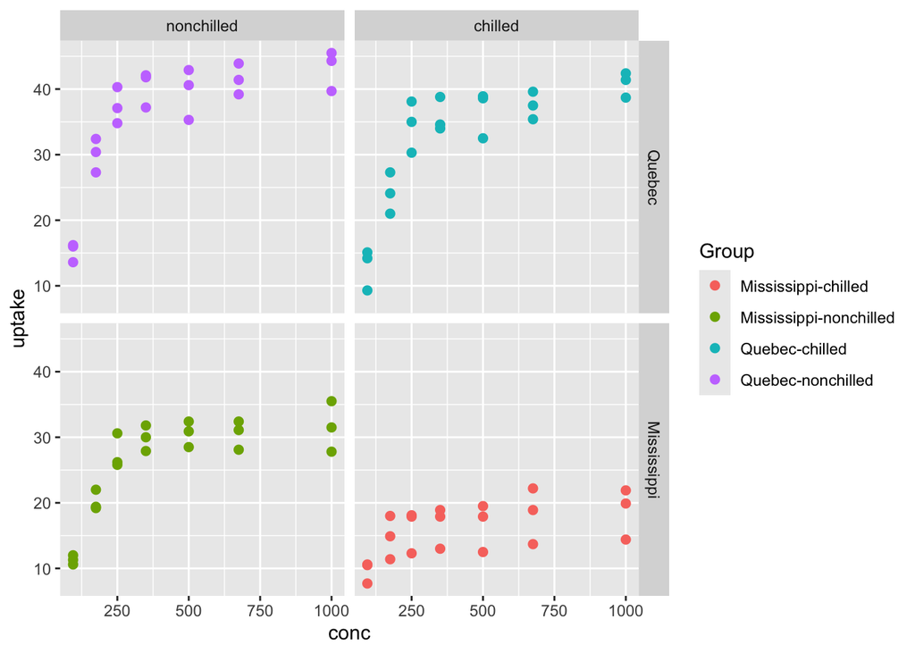

```r
# merge define subgroups based on Type and Treatment
CO2[, 'Group'] = paste(CO2[, 'Type'], CO2[, 'Treatment'], sep='-')
ggplot(CO2, aes(x=conc, y=uptake)) +
  geom_point(aes(color=Group), size = 2) +
  facet_grid(Type ~ Treatment)
```

The scatter plot illustrates the positive association of ambient CO2 concentration and the CO2 uptake by the plants.

# Task 8:

### install packages and load data

```r
# install packages
# install.packages('devtools')
# devtools::install_github("hirscheylab/tidybiology")

# load data
library(tidyverse)
library(tidybiology)
data('chromosome')
data('proteins')
```

### a. extract summary statistics in ‘chromosome’ data

```r
# I'm not using tidyverse functions here, cause it's easier for me to find a concise solution in base R.
cols_chr = c('variations', 'protein_codinggenes', 'mi_rna')
summary_chr = apply(chromosome[, cols_chr], 2, function(x) {
  c(mean=mean(x, na.rm=T),
    median=median(x, na.rm=T),
    maximum=max(x, na.rm=T))
})
summary_chr
```

```
##         variations protein_codinggenes    mi_rna
## mean       6484572            849.9583  73.16667
## median     6172346            836.0000  75.00000
## maximum   12945965           2058.0000 134.00000
```

### b. visualization of chromosome size distribution

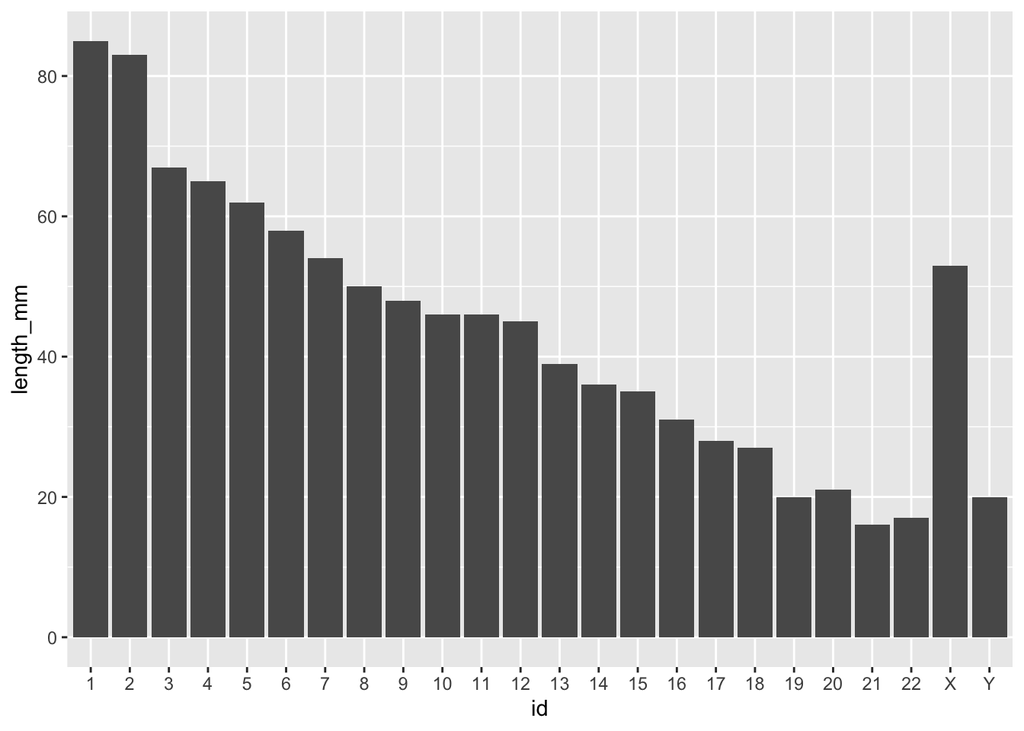

```r
library(ggplot2)
library(patchwork)
ggplot(data=chromosome, aes(x=id, y=length_mm)) + geom_col()
```

### c. visualization of relationships

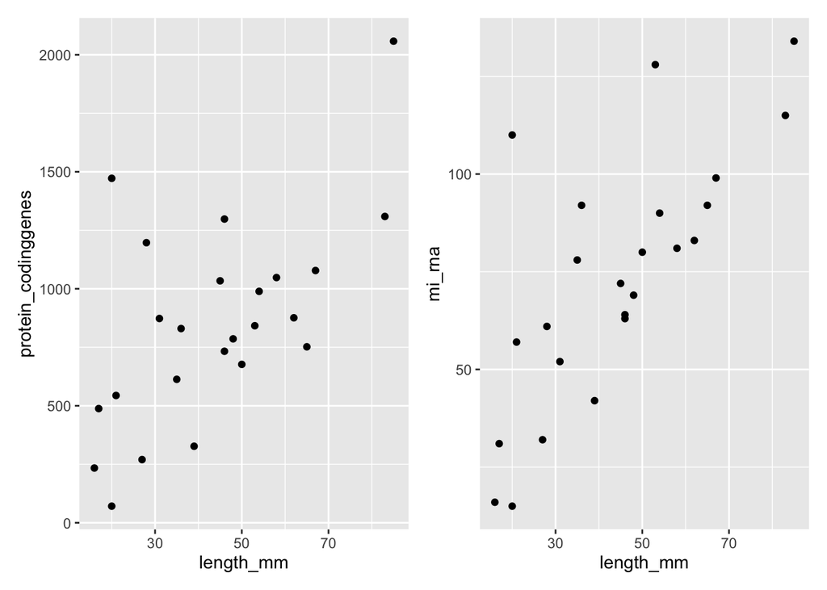

```r
p1 = ggplot(chromosome, aes(x=length_mm, y=protein_codinggenes)) +
  geom_point()
p2 = ggplot(chromosome, aes(x=length_mm, y=mi_rna)) +
  geom_point()

p1 + p2
```

Based on the plots, the chromosome size showed positive correlations with both the number of protein coding genes, and that of miRNAs.

### d. summarize the ‘protein’ data

```r
cols_protein = c('length', 'mass')
summary_protein = apply(proteins[, cols_protein], 2, function(x) {
  c(mean=mean(x, na.rm=T),
    median=median(x, na.rm=T),
    maximum=max(x, na.rm=T))
})
summary_protein
```

```
##             length       mass
## mean      557.1603   62061.38
## median    414.0000   46140.50
## maximum 34350.0000 3816030.00
```

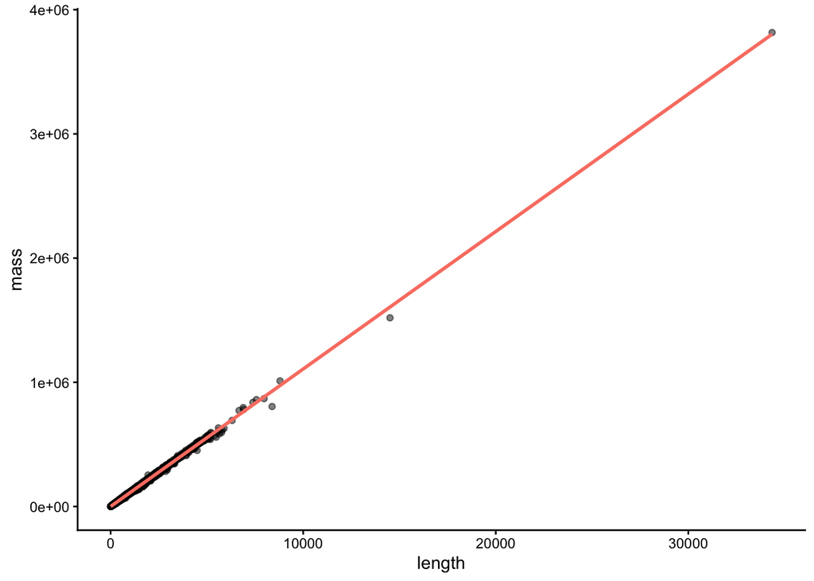

```r
ggplot(proteins, aes(x=length, y=mass)) +
  geom_point(alpha=0.5) +
  geom_smooth(method='lm', color="salmon", se=T) +
  theme_classic()
```